# Complex Data - Homework 4

Błażej Wiórek

5/27/2020

## Exercise 1: Inferences about the population

Calculations in this exercise are based on the following equations:

- Marginal mean: $\mathbb{E}[Y_i] = X_i\beta$, which yields:
  - For patients on drug A: $\hat{\mathbb{E}}(Y_{ij}|drug=A) = \hat{\beta}_1 + \hat{\beta}_3 time_{ij}$
  - For patients on drug B: $\hat{\mathbb{E}}(Y_{ij}|drug=B) = \hat{\beta}_1 + \hat{\beta}_2 + (\hat{\beta}_3+\hat{\beta}_4) time_{ij}$
- Marginal variance: $Var[Y_i] = Z_i G Z_i^T + R_i$ and due to assumption of conditional independence we have that $R_i = \sigma^2 I$

### Patient 1

#### Marginal mean

```
##      Marginal_Mean
## t_0       80.51400
## t_1       80.34955
## t_5       79.69173
## t_15      78.04719
## t_30      75.58038
## t_45      73.11357
```

#### Marginal variance

```
##            t_0       t_1       t_5      t_15      t_30     t_45
## t_0  132.15269 112.51142 109.99918 103.71859  94.29769 84.87680
## t_1  112.51142 130.90842 109.43033 103.26816  94.02490 84.78164
## t_5  109.99918 109.43033 126.16816 101.46645  92.93373 84.40100
## t_15 103.71859 103.26816 101.46645 115.97541  90.20580 83.44941
## t_30  94.29769  94.02490  92.93373  90.20580 105.12712 82.02201
## t_45  84.87680  84.78164  84.40100  83.44941  82.02201 99.60783
```

### Patient 2

#### Marginal mean

```
##      Marginal_Mean
## t_0       80.51400
## t_1       80.34955
## t_5       79.69173
## t_15      78.04719
## t_22      76.89601
## t_60      70.64676
```

#### Marginal variance

```
##            t_0       t_1       t_5      t_15      t_22     t_60
## t_0  132.15269 112.51142 109.99918 103.71859  99.32217 75.45591
## t_1  112.51142 130.90842 109.43033 103.26816  98.95464 75.53839
## t_5  109.99918 109.43033 126.16816 101.46645  97.48452 75.86828
## t_15 103.71859 103.26816 101.46645 115.97541  93.80921 76.69301
## t_22  99.32217  98.95464  97.48452  93.80921 110.24971 77.27033
## t_60  75.45591  75.53839  75.86828  76.69301  77.27033 99.41753
```

### Patient 13

#### Marginal mean

```
##      Marginal_Mean
## t_0       86.58879
## t_1       86.48257
## t_15      84.99553
## t_60      80.21576
```

#### Marginal variance

```
##            t_0       t_1      t_15     t_60
## t_0  132.15269 112.51142 103.71859 75.45591
## t_1  112.51142 130.90842 103.26816 75.53839
## t_15 103.71859 103.26816 115.97541 76.69301
## t_60  75.45591  75.53839  76.69301 99.41753
```

Plot below represents the trajectories of patients of interest. The trajectories for patient 1 and 2 overlaps because they are treated with the same drug. The only difference are points of measurments. Teajectory for patient 13 is siginificantly different in terms of intercept, but there’s only tiny difference in slope.

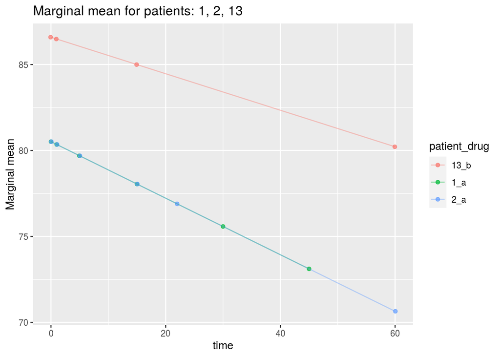

## Excercise 2: Two-Stage analysis: “NIH METHOD”

Stage 1:

- $Y_{ij} = intercept_i + slope_i*t_{ij} + \epsilon_{ij}$

Stage 2:

- $intercept_i = \beta_0 + \beta_1*Drug+\epsilon_{i1}$
- $slope_i = \beta_2 + \beta_3*Drug+\epsilon_{i2}$

Substituting equations from stage 2 into equation from stage 1 yields random intercept and slope model:
$$Y_{ij} = \beta_0 + \beta_1*Drug + \beta_2*t_{ij} + \beta_3 * Drug * t_{ij} + \epsilon_{ij}$$
Comparison of Two-Stage and Mixed Effects models:

```
##                    NIH:Estimate Mixed:Value NIH:Pr(>|t|) Mixed:p-value
## (Intercept)            80.45095    80.51400      0.00000       0.00000
## time                   -0.15903    -0.16445      0.00078       0.00007
## factor(drug)b           6.09799     6.07479      0.18556       0.18601
## time:factor(drug)b      0.05332     0.05824      0.36574       0.30405
```

When above observations are considered simultaneously it seems that the mean heart rate is decreasing over time but not due to drug application. It seems natural because process of application might be considered as stresfull and it may temporarily increase heart rate.